# Emade rinnapiima kolonisatsioon patogeensete bakteritega

Hiie Soeorg

## Sissejuhatus

Oma ema rinnapiima peetakse parimaks toiduks vastsündinule. Muude heade omaduste kõrval on rinnapiim oluline vastsündinute seedetrakti koloniseerivate bakterite allikas. Samas on leitud, et enneaegsetel vastsündinutel, kes on väga vastuvõtlikud infektsioonidele, võivad ema rinnapiimas leiduvad bakterid olla vereringeinfektsiooni põhjustajaks. Seetõttu on oluline teada, mis mõjutab rinnapiima mikroorganismide kooslust, et paremini välja töötada infektsioonide ennetamise meetmeid.

Käesoleva töö eesmärk on kirjeldada enneaegsete ja ajaliste vastsündinute emade rinnapiima kolonisatsiooni võimalike patogeensete bakteritega, võimalike patogeensete bakterite leidumist mõjutavaid tegureid ja patogeenseid baktereid sisaldava rinnapiimaga toitmise mõju vastsündinule. Sellised teadmised aitavad hinnata, kui suur võiks olla infektsiooni risk enneaegsete vastsündinute jaoks ema rinnapiimaga toitmisel ja kuidas seda riski vähendada.

Andmed on pärit SA Tartu Ülikooli Kliinikumis ja SA Tallinna Lastehaiglas koostöös Tartu Ülikooli bio- ja siirdemeditsiini instituudi mikrobioloogia osakonnaga aastatel 2014-2015 läbi viidud prospektiivsest uuringust, milles jälgiti kahte vastsündinute ja nende emade kohorti. Kokku oli uuringus 49 intensiivravi osakonda hospitaliseeritud enneaegset vastsündinut ja nende ema ning 20 tervet ajalist vastsündinut ja nende ema, kes olid haiglast koju lubatud. Mõlemaid kohorte jälgiti 1 kuu jooksul pärast sünnitust ja registreeriti nendega tehtud meditsiinilised toimingud, tekkinud haigused ja kehapiirkondade kolonisatsioon mikroorganismidega. Kehapiirkondadest uuriti vastsündinutel seedetrakti (roojaproovi) ja nahka (kaenla all) ja emalt rinnapiima, milleks koguti üks kord nädalas esimese kuu jooksul pärasti sünnitust proove, millest isoleeriti bakterid.

## Bakterite esinemissagedus rinnapiima proovides

Kõigepealt uurime, missuguseid baktereid ja kui paljudes rinnapiima proovides üldse oli. Uurime seda enneaegsete ja ajaliste vastsündinute emade gruppides eraldi, sest olulised bakterite kooslust mõjutavad faktorid on antibiootikumravi ja haiglaravi. Enneaegsete vastsündinute emad said nii antibakteriaalset ravi kui ka vajasid haiglaravi sagedamini kui ajaliste vastsündinute emad. Allpool toodud tulpdiagrammidel on haiglaravi ja antibiootikumravi pikkuste jaotus enneaegsete vastsündinute emadel enne ja pärast sünnitust. Ajaliste vastsündinute emad viibisid haiglaravil ainult sünnituse tõttu (mediaan 2 päeva (ulatus 0 kuni 3 päeva) ) ja antibiootiumravi ei vajanud.

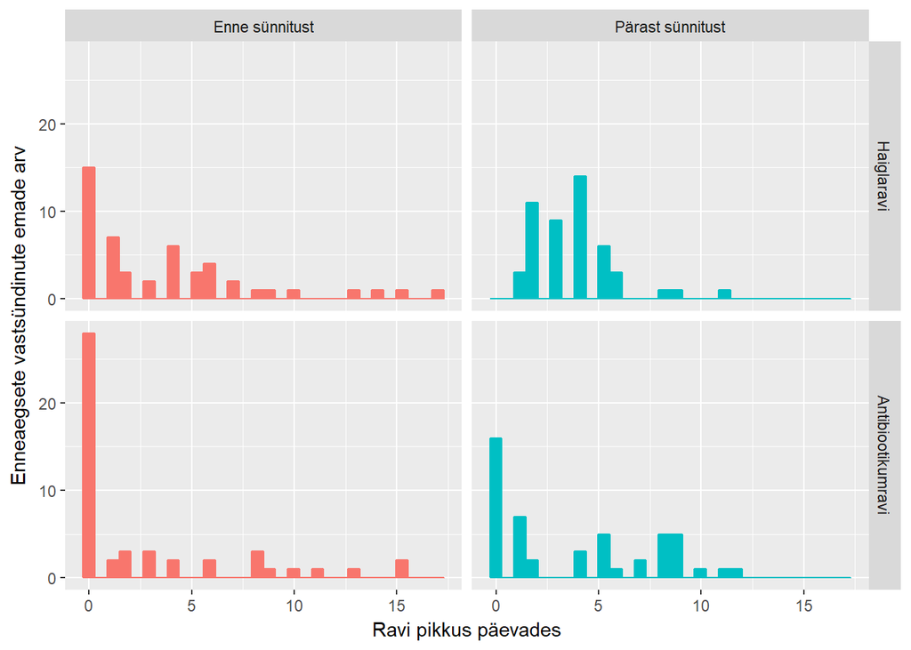

Kuna need kaks olulist bakterite kooslust mõjutavat faktorit erinevad enneaegsete ja ajaliste vastsündinute emadel, siis võib ka bakterite esinemissagedus proovides olla erinev enneaegsete ja ajaliste vastsündinute emadel. Allpool toodud tulpdiagramm näitab, kui mitmes proovis (kokku 69 emalt 251 proovi) vastavat bakterit vastavas emade grupis leidus.

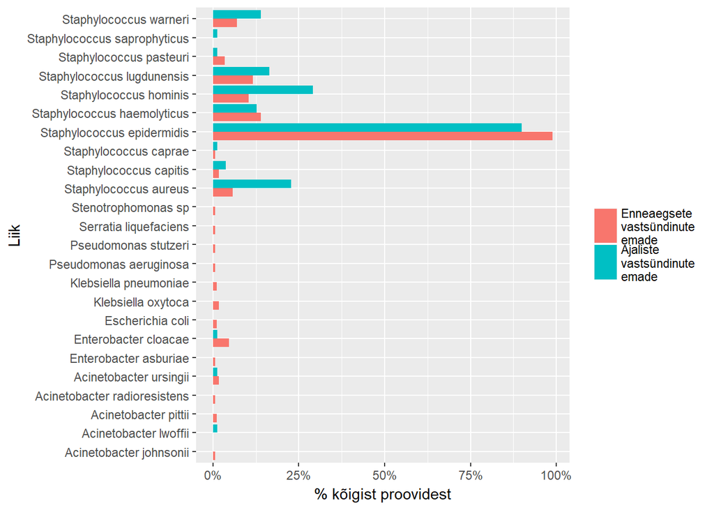

Tulemused kinnitavad varasemaid uuringuid, et stafülokokid on väga sagedased rinnapiima bakterid. Seejuures on mitmeid stafülokokkide liike sagedamini ajaliste vastsündinute emade rinnapiimas, võrreldes enneaegsete vastsündinute emadega, viidates väiksemale mitmekesisusele enneaegsete vastsündinute emadel.

Kuna teised bakterite liigid peale stafülokokkide võivad põhjustada enneaegsetel vastsündinutel raskemaid infektsioone, siis keskendub käesolev töö just nendele. Tulpdiagrammilt näeme, et need teised uuritud bakterite liigid olid pigem enneaegsete vastsündinute emade rinnapiimas ja harvem ajaliste vastsündinute emade rinnapiimas.

Olgugi et erinevad stafülokokid olid pigem sagedasemad ajaliste vastsündinute emadel ja teised bakterid enneaegsete vastsündinute emadel, kuid peakomponentanalüüsi põhjal ei selgu, et enneaegsete ja ajaliste vastsündinute emade rinnapiima proove saaks eristada mikroobide koosluse põhjal. Seda näitab selgelt eristuvate klastrite puudumine, nagu allpool oleval esimest ja teist peakomponenti visualiseerival joonisel näha.

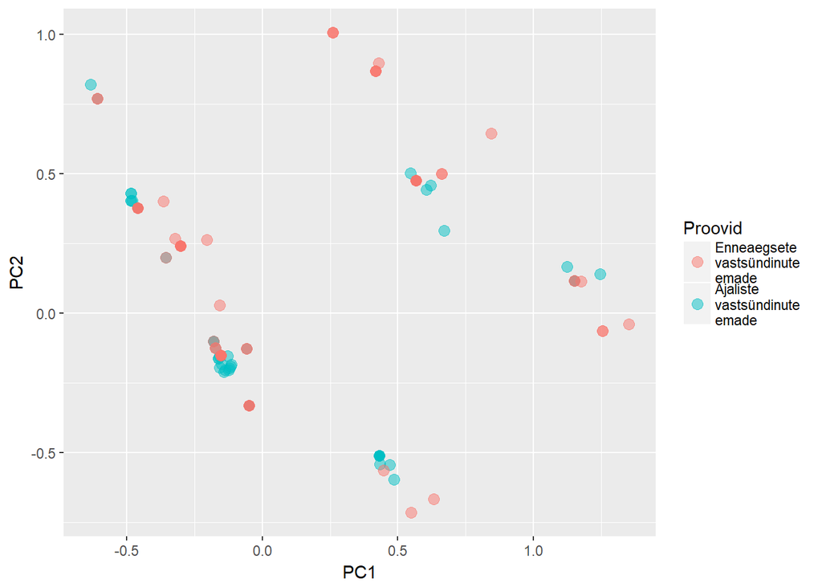

## Rinnapiima proovides patogeensete bakterite olemasoluga seotud faktorid

Kuna just nende bakterite liigid, mis olid sagedasemad ennaegsete vastsündinute emade rinnapiima proovides, (perekondadest *Pseudomonas*, *Acinetobacter*, *Enterobacter*, *Klebsiella*, *Escherichia*, *Serratia*, *Stenotrophomonas*) on seotud suurema suuremusega nende poolt põhjustatud infektsioonide korral, siis uurime, missugused faktorid on seotud nende olemasoluga rinnapiimas. Faktorid, mis võivad bakteritega kolonisatsiooni mõjutada, on raseduse kestus, sünnituse viis, aeg pärast sünnitust, kokkupuude vastsündinu intensiivraviosakonnaga, haiglas viibimine, antibiootikumravi, vastsündinu kolonisatsioon, eelmise ja uuritava proovi koostis. Analüüsis võtame arvesse, et ühelt emalt pärit proovid on omavahel seotud (juhusliku mõjuna segamõjudega logistilises regressioonanalüüsis). Allpool toodud joonis näitab, kas ja kui palju y-teljel toodud faktor suurendab šansse, et rinnapiimas on võimalik patogeen olemas.

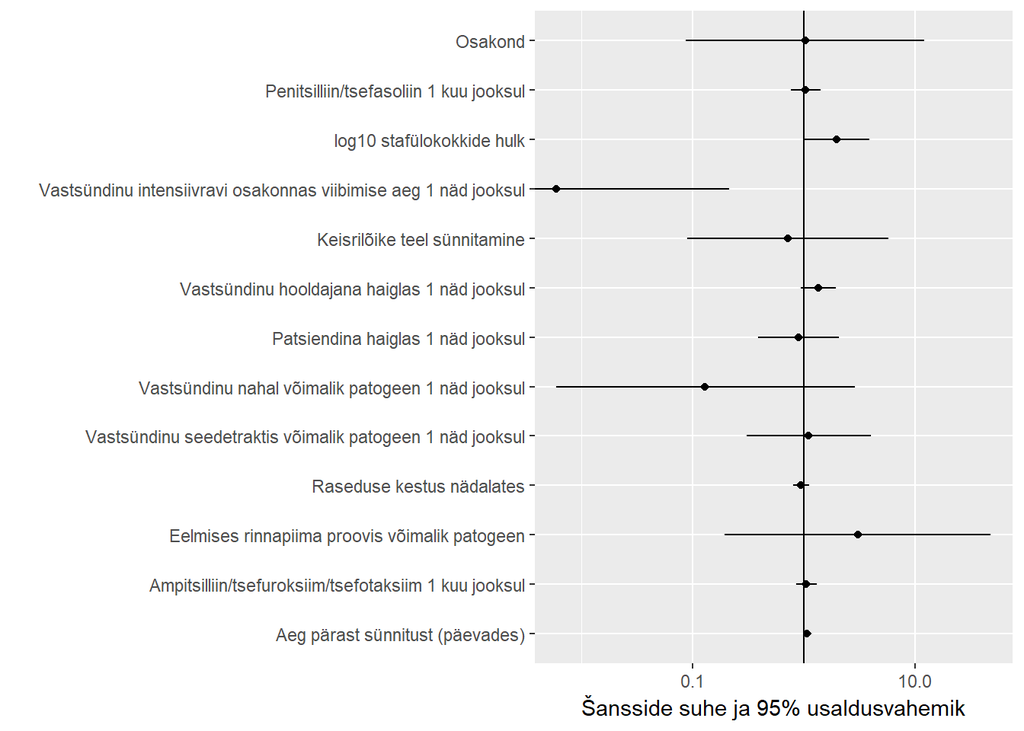

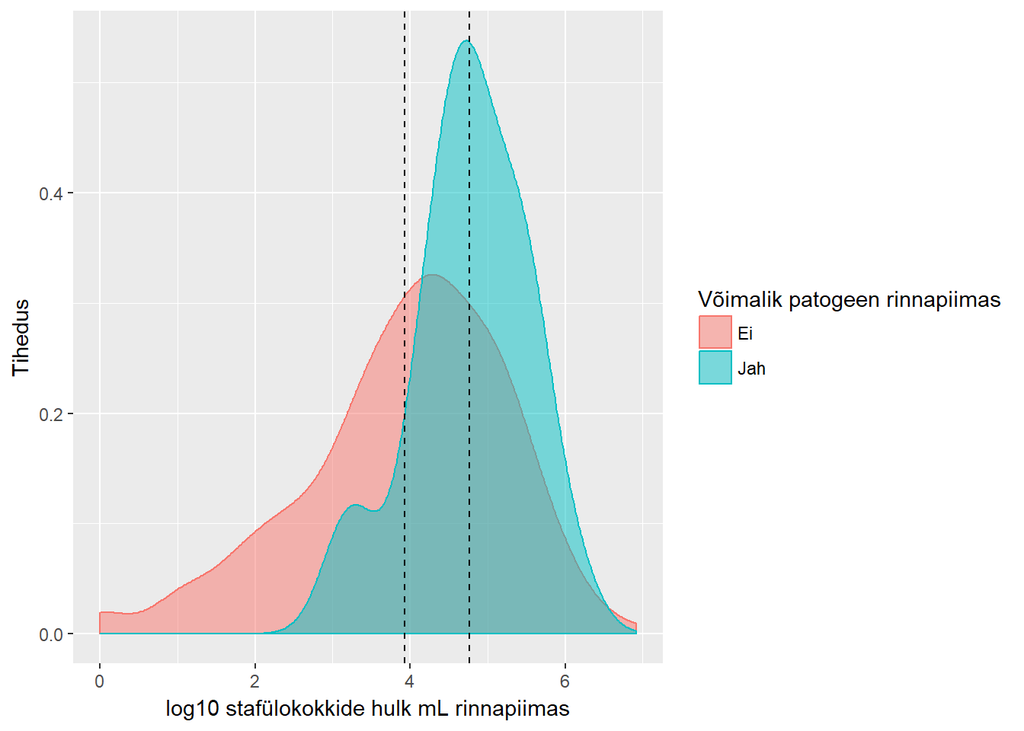

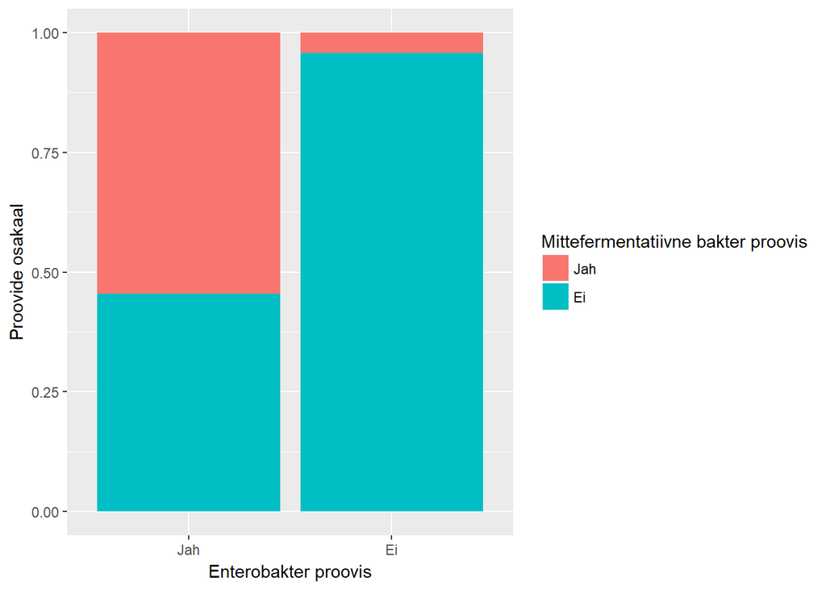

## Enneaegsete vastsündinute ravi ja ema rinnapiimas patogeensete bakterite olemasolu vaheline seos

Võimalikud patogeensed bakterid võivad mõjutada enneaegsete vastsündinute haiguste teket ja ravi kestust intensiivraviosakonnas. Seetõttu uurisime, kas on erinevusi enneaegsete vastsündinute vahel, kelle emal mingis proovis oli võimalik patogeenne bakter või mitte. Analüüs on kohandatud raseduse kestusele ja rinnapiima hulgale, mida vastsündinule manustati, sest need mõlemad on väga olulised ravi kestust mõjutavad faktorid. Allpool toodud jooniselt näeme, et šansid pikemaks raviks või haiguse tekkeks ei erinenud, kui emal oli rinnapiima proovis võimalik patogeenne bakter olemas või mitte.

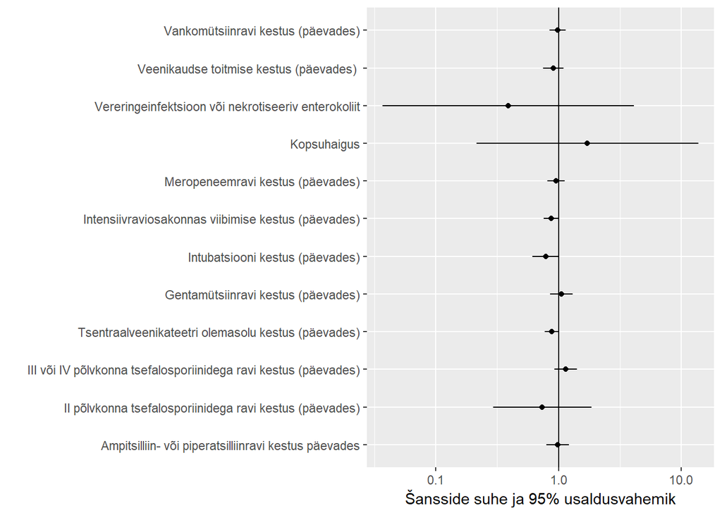

## Rinnapiima ja vastsündinu kolonisatsiooni vaheline seos

Rinnapiima bakterid võivad koloniseerida vastsündinut, peamiselt seedetrakti. Seetõttu võib seedetrakti kolonisatsioon olla erinev vastsündinutel, kelle ema rinnapiimas on võimalik patogeenne bakter, võrreldes nendega, kelle ema rinnapiimas ei ole sellist bakterit. Peakomponentanalüüsi järgi siiski ei eristu vastsündinute seedetrakti koloniseerivate bakterite kooslus selle põhjal, kas ema rinnapiimas oli võimalik patogeenne bakter või mitte.

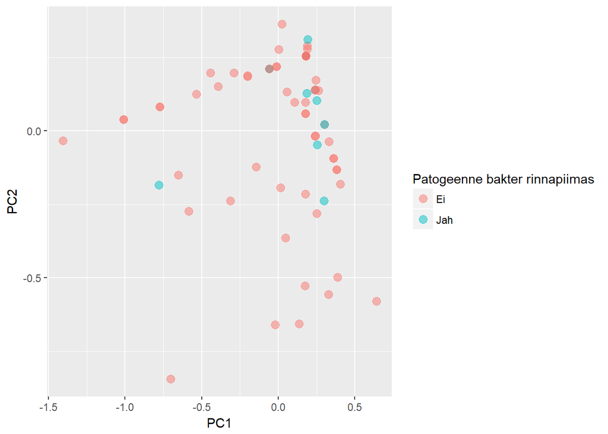

Kuna erinevaid võimalikke patogeenseid baktereid oli mitmeid ema rinnapiimas, siis võib olla seos rinnapiima ja vastsündinu kolonisatsiooni vahel, vaadates täpsemalt liigi tasemel. Allpool toodud joonis näitab, kuidas oli erinevate võimalike patogeensete bakterite liikide jaotus isolaatide hulgas, mis isoleeriti vastsündinu seedetraktist, nahalt ja ema rinnapiimast. Näeme, et enneaegsete vastsündinute emadelt ja nende vastsündinutelt isoleeritud bakterite hulgas oli liikide jaotuses sarnasust. Suurem osa bakteritest kuulus liiki *Enterobacter asburiae*, *Enterobacter cloacae*, *Escherichia coli*, *Klebsiella oxytoca* või *Klebsiella pneumoniae*. Ajaliste vastsündinute ja nende emade puhul märgatavat sarnasust ei näi olevat.

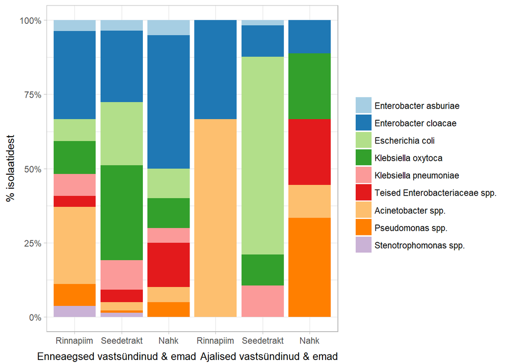

Seetõttu uurime, kas on olemas korrelatsioon sagedasemate bakterite hulka kuuluva liigiga enneaegsete vastsündinute nahal ja seedetraktis ja nende emade rinnapiimas. Selgub, et on mõõdukas positiivne korrelatsioon vastsündinu seedetraktis ja ema rinnapiimas leiduva *Enterobacter asburiae* isolaatide arvu vahel ning rinnapiimas ja vastsündinu nahal leiduva *Escherichia coli* isolaatide arvu vahel. Järelikult vastsündinu ja ema kolonisatsiooni vahel võib olla positiivne seos, kuid tuleb arvestada, et antud uuringus oli koloniseeritud emade arv väike.

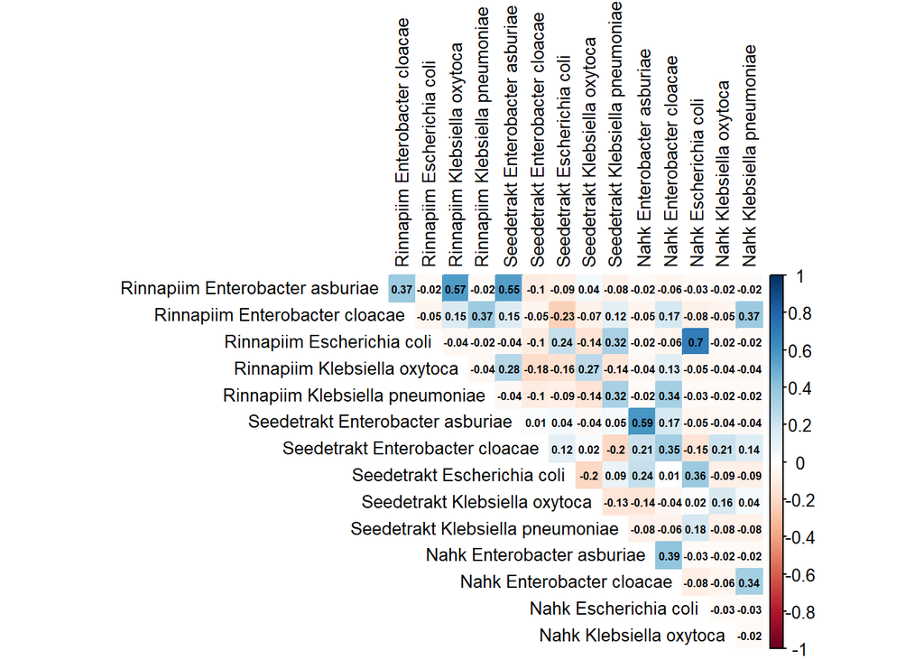

## Kokkuvõte

Töös selgus kolm olulisemat tulemust rinnapiima kolonisatsiooni kohta. Esiteks, vastsündinute emade rinnapiimas leidub võimalike patogeenseid baktereid harva. Teiseks, ei selgunud, et rinnapiima võimalike patogeensete bakteritega kolonisatsiooni mõjutaks ühed olulisemad bakterite kooslust mõjutavad tegurid - antibiootikumravi ja haiglaravi. Kolmandaks, enneaegsete vastsündinute emade rinnapiima kolonisatsioon võimalike patogeensete bakteritega ei mõjuta vastsündinu haiguste teket ega ravi kestust ning ei ole ka selgelt seotud vastsündinu naha või seedetrakti kolonisatsiooniga. Seega on rinnapiimast võimalike patogeensete bakterite poolt tekitatud risk vastsündinu jaoks väike.